# STAT 385 Statistics Programming Methods - Fall 2020

### Facets

Adding facets can be helpful for displaying various categories, levels, or discrete values for the data you’re visualizing. It creates subsets of the data with headers in the plot to remind users of what’s being shown.

With one categorical variable, use `facet_wrap`, with two variables use `facet_grid`.

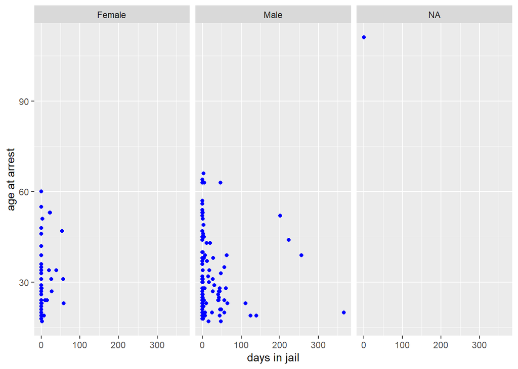

```r
ggplot(data = jail) +
  geom_point(mapping = aes(x = `days in jail`, y = `age at arrest`), color = "blue") +
  facet_wrap( ~ factor(sex))
```

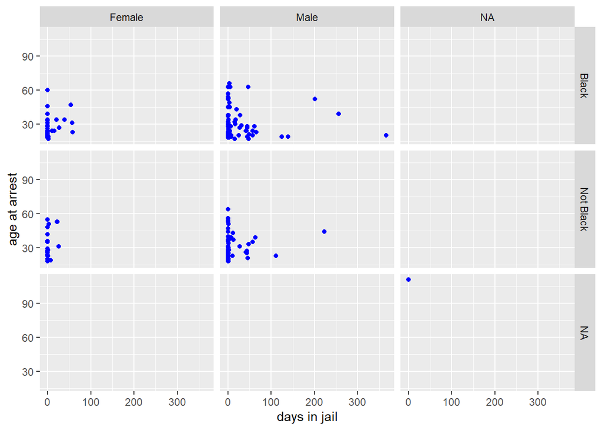

```r
ggplot(data = jail) +
  geom_point(mapping = aes(x = `days in jail`, y = `age at arrest`), color = "blue") +
  facet_grid( factor(race2) ~ factor(sex))
```

### Geometric objects

There are several kinds of geometric objects we can show. These geometric objects include points for scatter plots, bars for bar charts, lines for line plots, and more. We already saw the `geom_points` layer above.

- `geom_bar` for bar charts works when we the frequencies are coming directly from the data and not from a contingency table or summary table

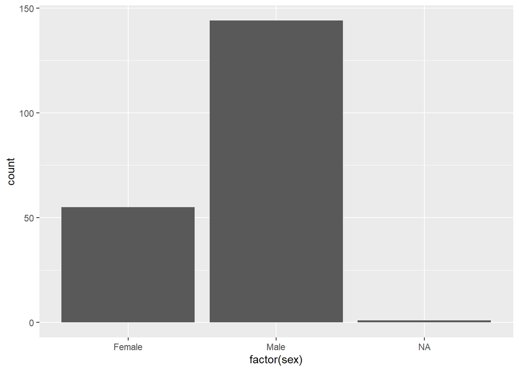

```r
ggplot(data = jail ) +
  geom_bar(mapping = aes(x = factor(sex)))
```

- `geom_col` for bar charts works well when the data is in a contingency table or summary table

```r
jail3 <- jail %>%
  group_by(race2, sex) %>%
  summarise(counts=n())
```

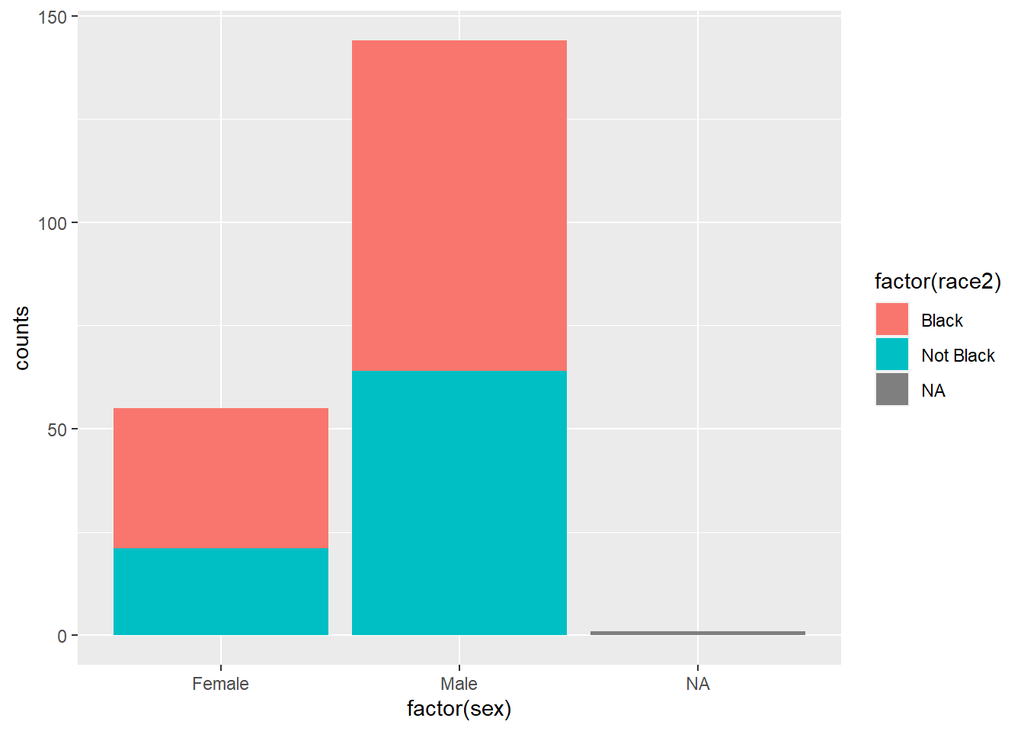

```r
ggplot(data = jail3 ) +
  geom_col(mapping = aes(x = factor(sex), y=counts, fill=factor(race2)))
```

- `geom_boxplot` for box plots

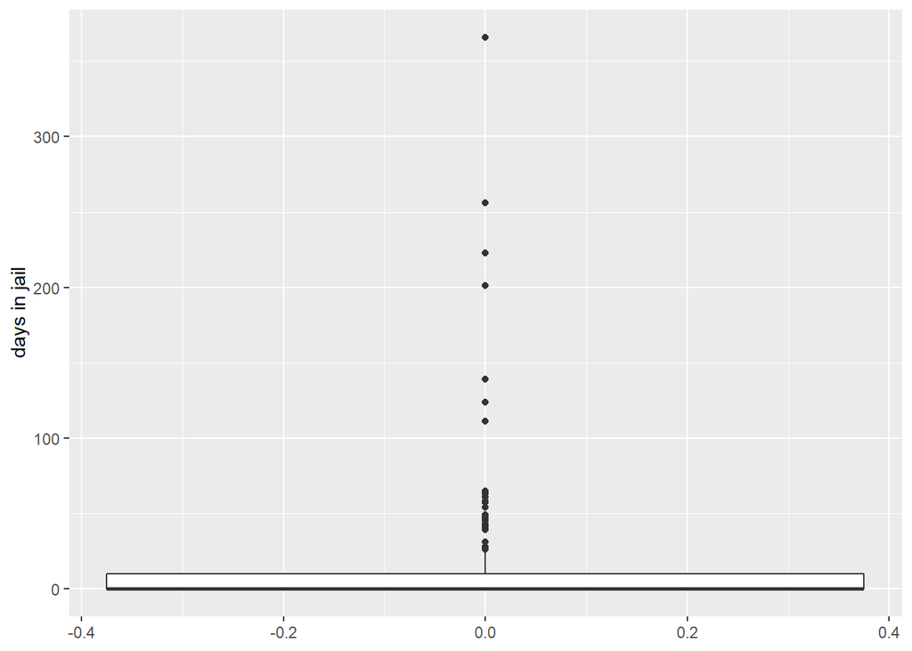

```r
ggplot(data = jail ) +
  geom_boxplot(mapping = aes(y = `days in jail`))
```

- `geom_density` for kernel density estimates

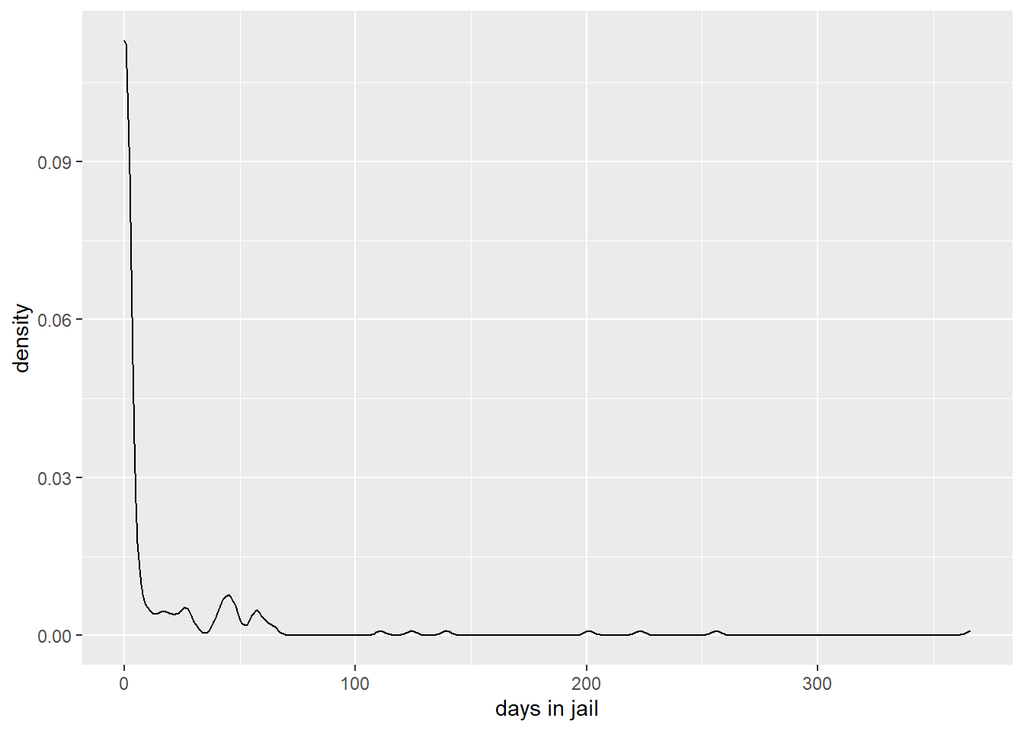

```r
ggplot(data = jail ) +
  geom_density(mapping = aes(x = `days in jail`))
```

- `geom_histogram` for histograms

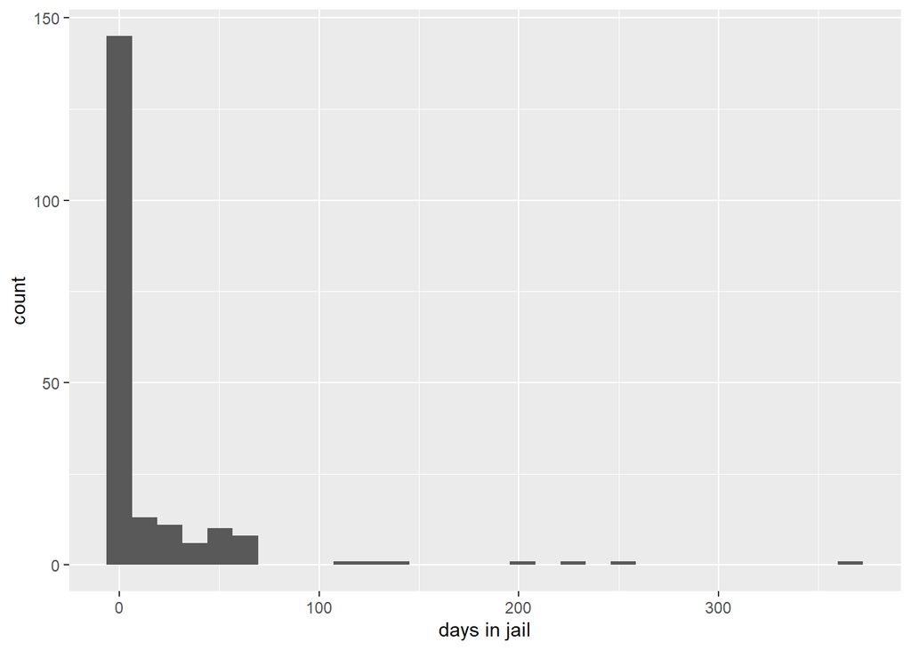

```r
ggplot(data = jail ) +
  geom_histogram(mapping = aes(x = `days in jail`))
```

- `geom_text` for adding text to plots

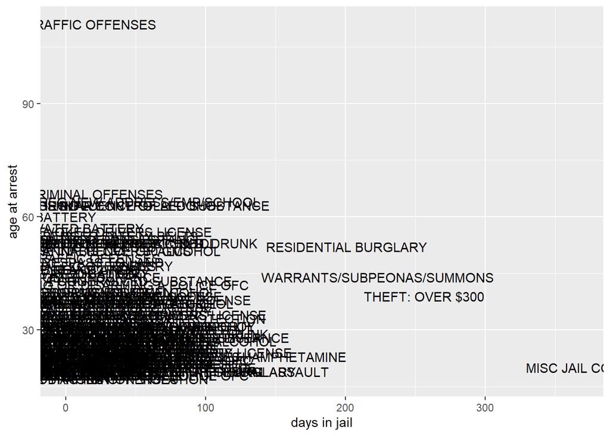

```r
ggplot(data = jail ) +
  geom_text(mapping = aes(x = `days in jail`, y = `age at arrest`, label = `crime code`) )
```

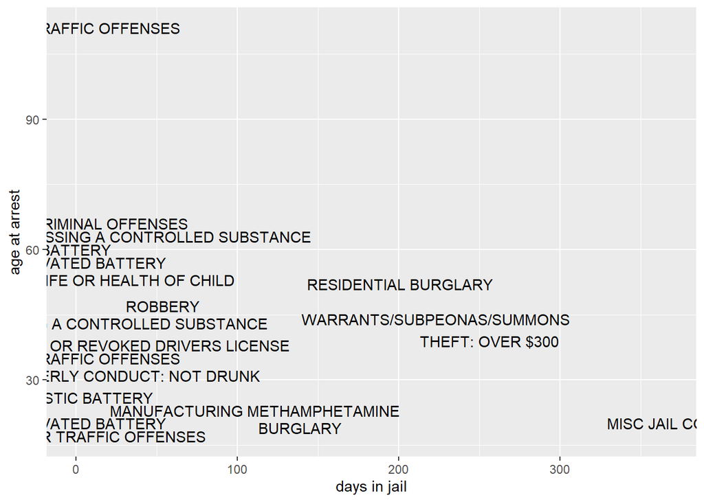

```r
#VS

ggplot(data = jail ) +
  geom_text(mapping = aes(x = `days in jail`, y = `age at arrest`, label = `crime code`), check_overlap=TRUE)
```

- `geom_violin` violin plots (similar to bean plots)

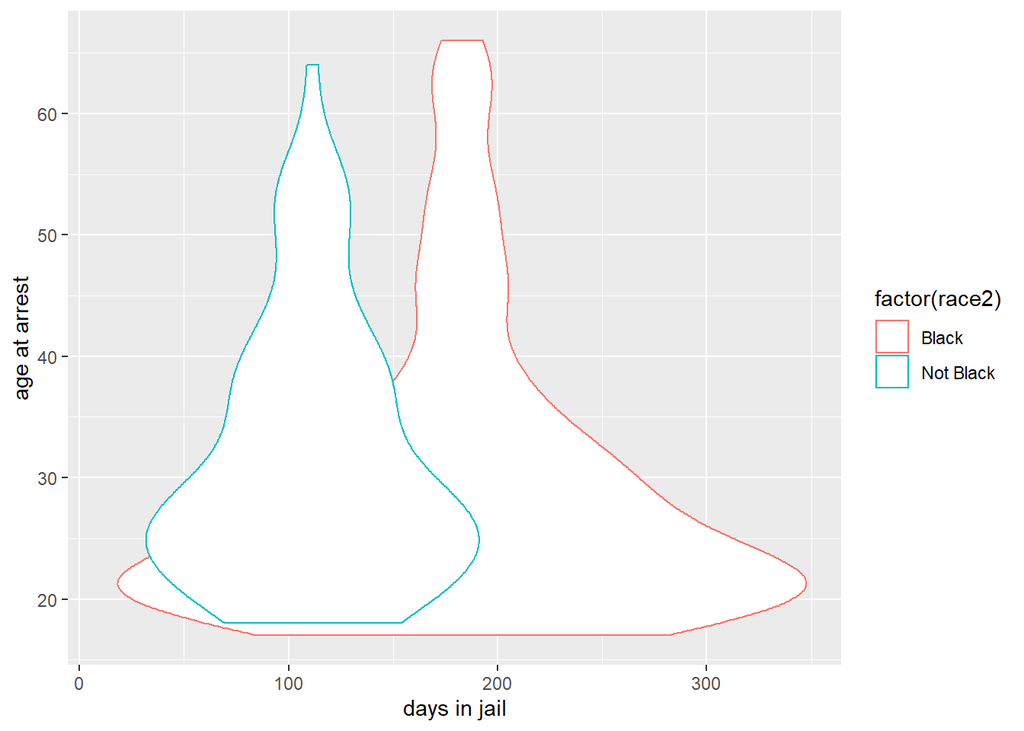

```r
ggplot(data = jail ) +
  geom_violin(mapping = aes(x = `days in jail`, y = `age at arrest`, color = factor(race2)) )
```

We can have multiple geom functions for the same data.

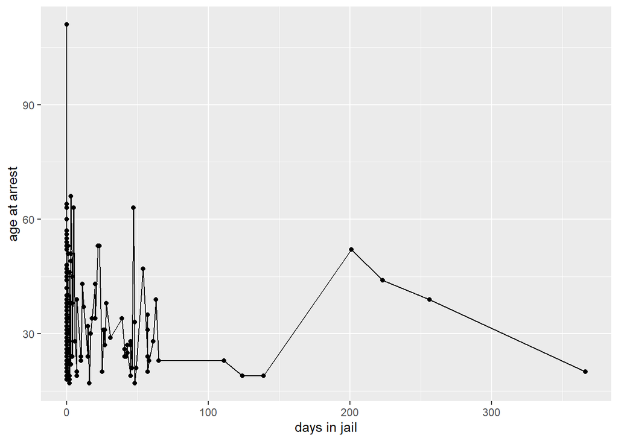

```r
ggplot(data = jail) +
  geom_point(mapping = aes(x = `days in jail`, y = `age at arrest`)) +
  geom_line(mapping = aes(x = `days in jail`, y = `age at arrest`))
```

Or we can have same geom functions for multiple data.

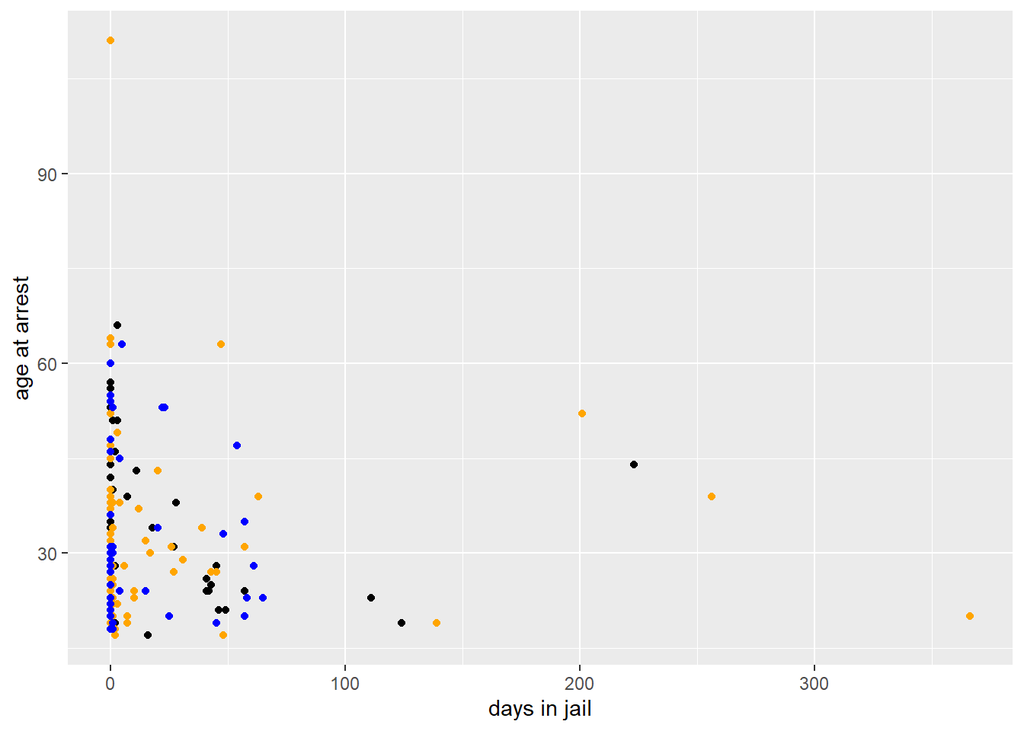

```r
ggplot(data = jail, mapping = aes(x = `days in jail`, y = `age at arrest`)) +
  geom_point() +
  geom_point(data = filter(jail, city == "CHAMPAIGN"), color="orange") +
  geom_point(data = filter(jail, city == "URBANA"), color="blue")
```

### Position adjustments

We can change how the geometric objects are oriented in a plot through a position adjustment as a mapping. Different geometric objects benefit from certain position changes.

- `position_fill` fills in objects with colors

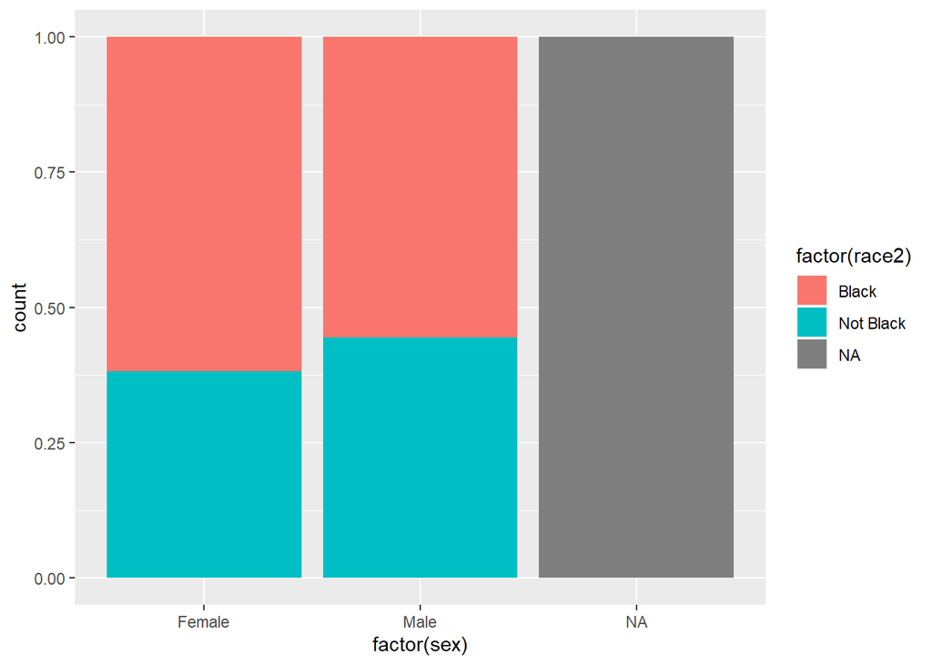

```r
ggplot(data = jail ) +
  geom_bar(mapping = aes(x = factor(sex), fill = factor(race2)) , position= "fill")
```

- `position_dodge` shifts bars side-by-side aka clustered aka grouped

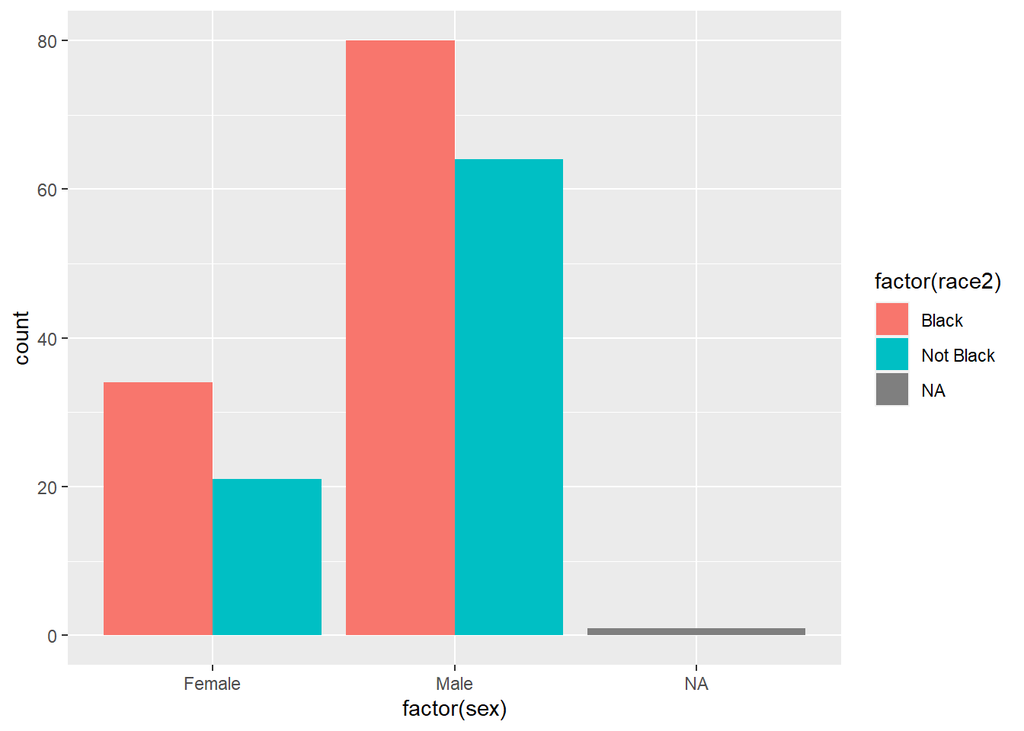

```r
ggplot(data = jail ) +
  geom_bar(mapping = aes(x = factor(sex), fill = factor(race2)), position = "dodge" )
```

- `position_jitter` moves repeated or duplicate points slightly

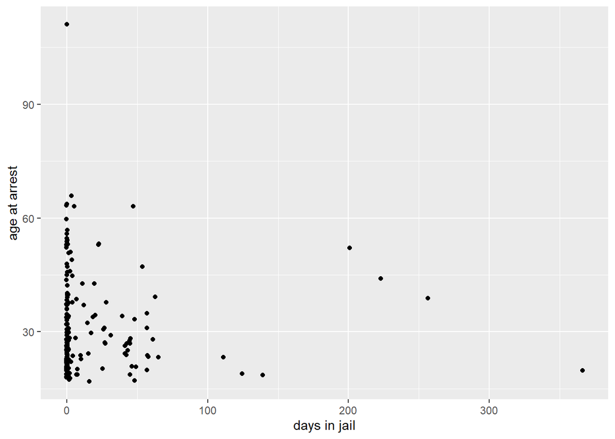

```r
ggplot(data = jail) +
  geom_point(mapping = aes(x = `days in jail`, y = `age at arrest`),  position="jitter")
```

- `position_stack` changing the stacking of bars

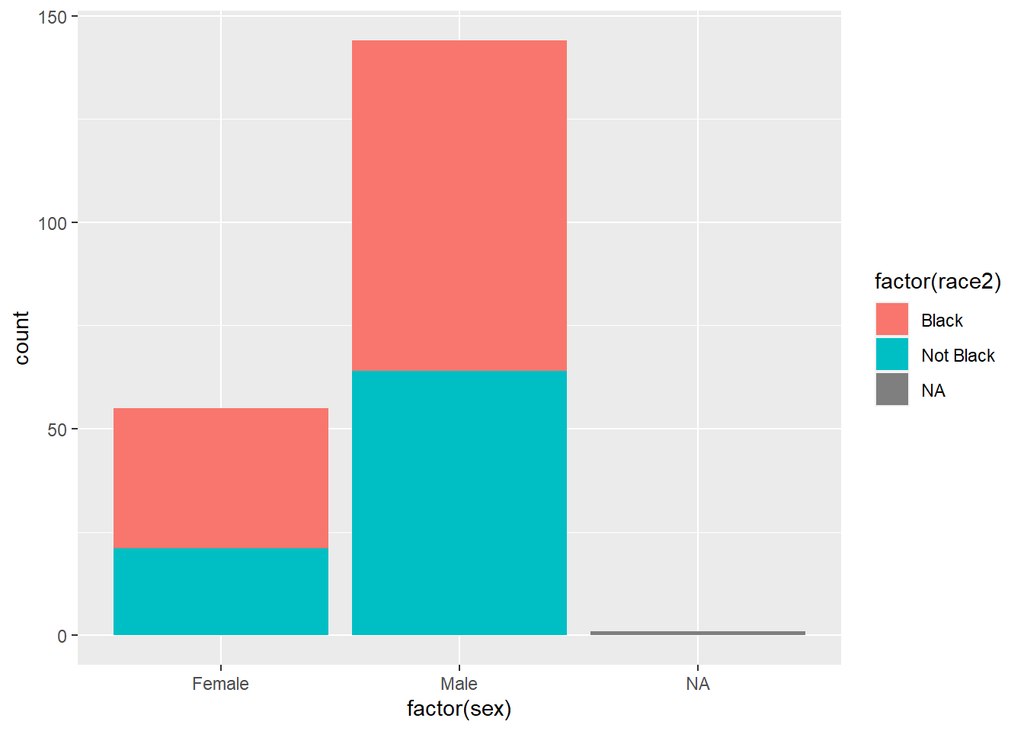

```r
ggplot(data = jail ) +
  geom_bar(mapping = aes(x = factor(sex), fill = factor(race2)) , position = "stack")
```

- `coord_flip()` can make vertical bars become horizontal bars

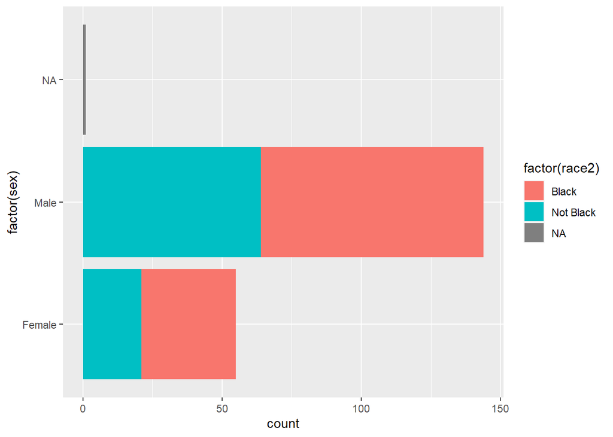

```r
ggplot(data = jail ) +
  geom_bar(mapping = aes(x = factor(sex), fill = factor(race2)) , position = "stack") +
  coord_flip()
```

### Adding titles, captions, and labels

We can use very specific functions to add labels and titles within ggplot using `labs()` and `guides()`. The possibilities are numerous and I won’t list them all here. See https://ggplot2.tidyverse.org/reference/labs.html for more details on labels. See https://ggplot2.tidyverse.org/reference/guide_legend.html for more details on legends.

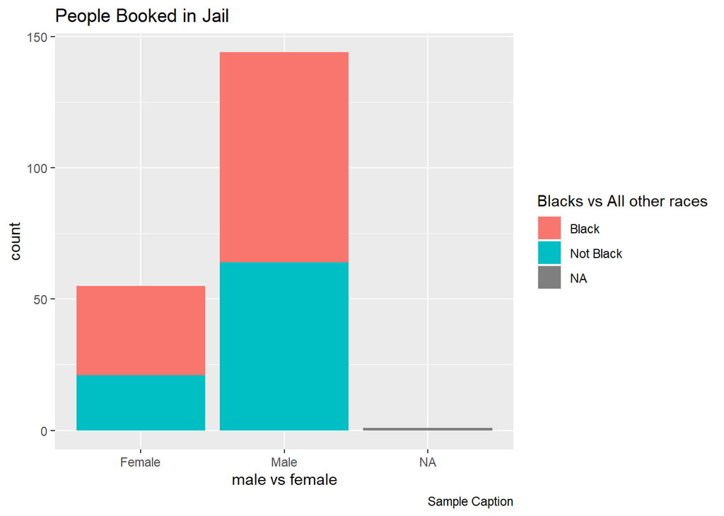

```r
ggplot(data = jail ) +
  geom_bar(mapping = aes(x = factor(sex), fill = factor(race2)) , position = "stack") +
  labs(x= "male vs female", title = "People Booked in Jail", caption="Sample Caption") +
  guides(fill = guide_legend(title = "Blacks vs All other races"))
```

### Suppressing plot elements in order to add elements

Suppressing elements in ggplot can be very specific to the element we want to suppress, but we usually need to change an argument’s value to `element_blank()`. Often suppression comes through modifying the themes `themes()`. See https://ggplot2.tidyverse.org/reference/theme.html for more details on modifying themes.

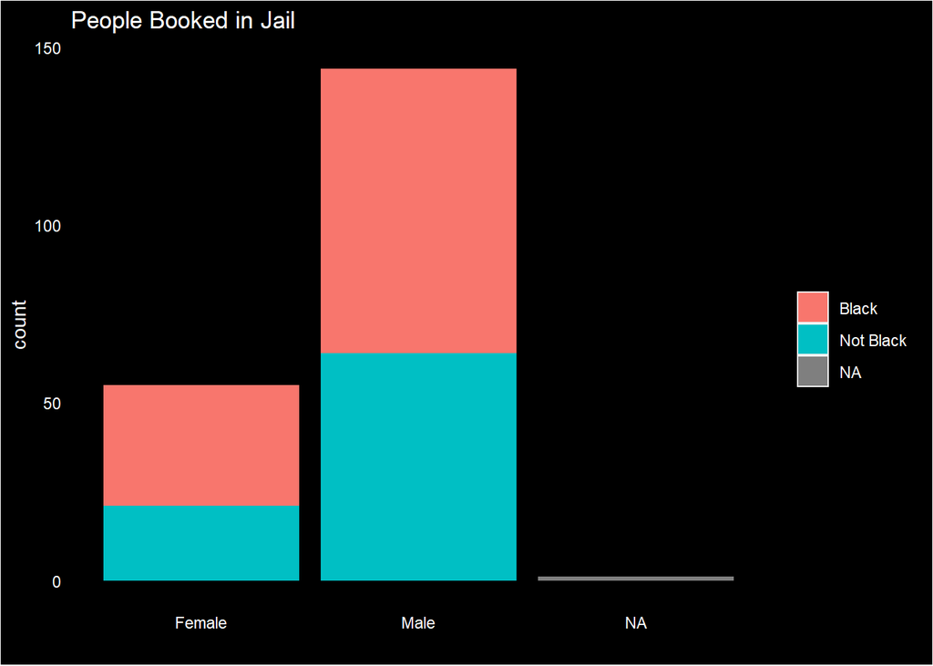

```r
ggplot(data = jail ) +
  geom_bar(mapping = aes(x = factor(sex), fill = factor(race2)) , position = "stack") +
  theme(plot.background = element_rect(fill="black"), panel.background = element_rect(fill = "black"), axis.ticks=element_blank(), axis.text = element_text(color = "white"), panel.grid=element_blank(), legend.background = element_rect(fill = "black"), axis.title = element_text(color = "white"), legend.text = element_text(color = "white"), plot.title = element_text(color = "white")) +
  labs(x= "", title = "People Booked in Jail")
```

## Visual design principles

We now shift to covering topics of Chapters 1-5 in **Storytelling with Data** by C. Knaflic. The Knaflic uses Microsoft Excel to create all visualizations in the book. The R code and plots below are created with R’s standard data importing - `read.csv` - and graphics device - the `plot` function. I challenge all students to recreate these visualizations with tidyverse’s functionality.

### **Storytelling with Data** *Ch. 1 The Importance of Context*

#### Who: You need to know your audience

- Audiences can be very detail-oriented, big-picture-oriented, or anywhere in between.
- In this class, the audience is usually the Instructor, but sometimes the other students.
- At work, the audience may be your client, supervisor, or team.
- You **must** to alter your data visualization and storytelling for that audience.

#### What: What do you want the audience to know or do?

- In this class, the what may be subject specific, but is usually follows the highest marks on the rubric, i.e. that you were
- thorough in analysis and thought
- efficient in coding and organization
- precise in your execution
- mindful of creating beautiful visualizations, presentations, and demonstrations.

#### How: How you will you deliver the what?

- Consider what needs to happen in order for the visualization or presentation to be interpreted well. Do those things.
- Creating simple storyboards with pen and paper will help in organizing your story/presentation/demonstration

As an example of the importance of context, suppose you were to conduct an investigative data analysis project on the full **Champaign County Sheriffs Office Bookings Data**.

```r
jail$days2 <- as.numeric(jail$`days in jail`)
jail$date2 <- as.Date(jail$`booking date`, "%m/%d/%Y")
jail$year2 <- format(jail$date2, "%Y")
jail$weeksbin <- ifelse(jail$days2 > 6,"At Least 1 Week","Less Than 1 Week")
jail$blackbin <- ifelse(jail$race=="Black","Black","Non-black")
```

**Who** : Instructor who considers Champaign County his home; a black man who is concerned with over-policing and unnecessary incarceration of poor black people

**What** : Champaign County bookings for black people versus other racial and ethnic groups, the relationships between race and other demographics, and time spent in jail

**How** : Illustrate booking frequencies for race vs time spent in jail vs crime code

### **Storytelling with Data** *Ch. 2 Choosing an Effective Visual*

#### Text

- When there are only a few numbers to show (~ 4 or less), using text may be more effective than a table

**BAD**

```r
rb <- c(sum(jail$race2[jail$year2=="2011"]=="Black", na.rm = TRUE)/length(jail$race2[jail$year2=="2011"]),
        sum(jail$race2[jail$year2=="2016"]=="Black", na.rm = TRUE)/length(jail$race2[jail$year2=="2016"]))
rbp <- barplot( rb, main="Booking Rate of Black People")
rbp
```

```
##      [,1]
## [1,]  0.7
## [2,]  1.9
```

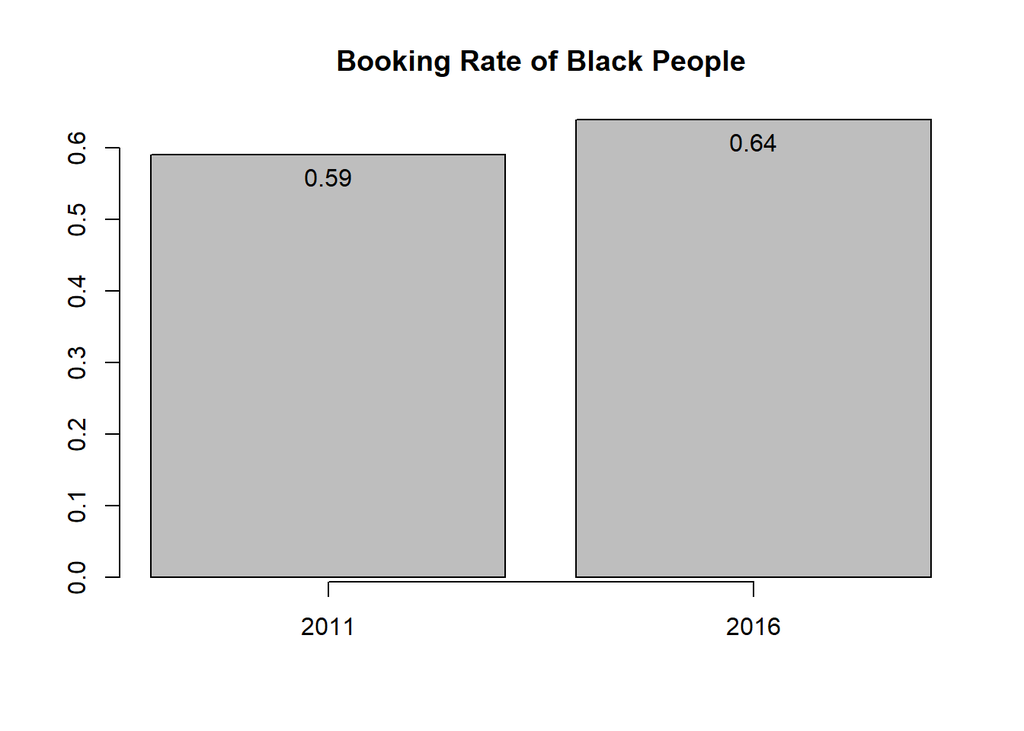

```r
text(rbp, rb, label=round(rb,2), pos=1)
axis(1, at=rbp, labels=c("2011","2016"))
```

**GOOD**

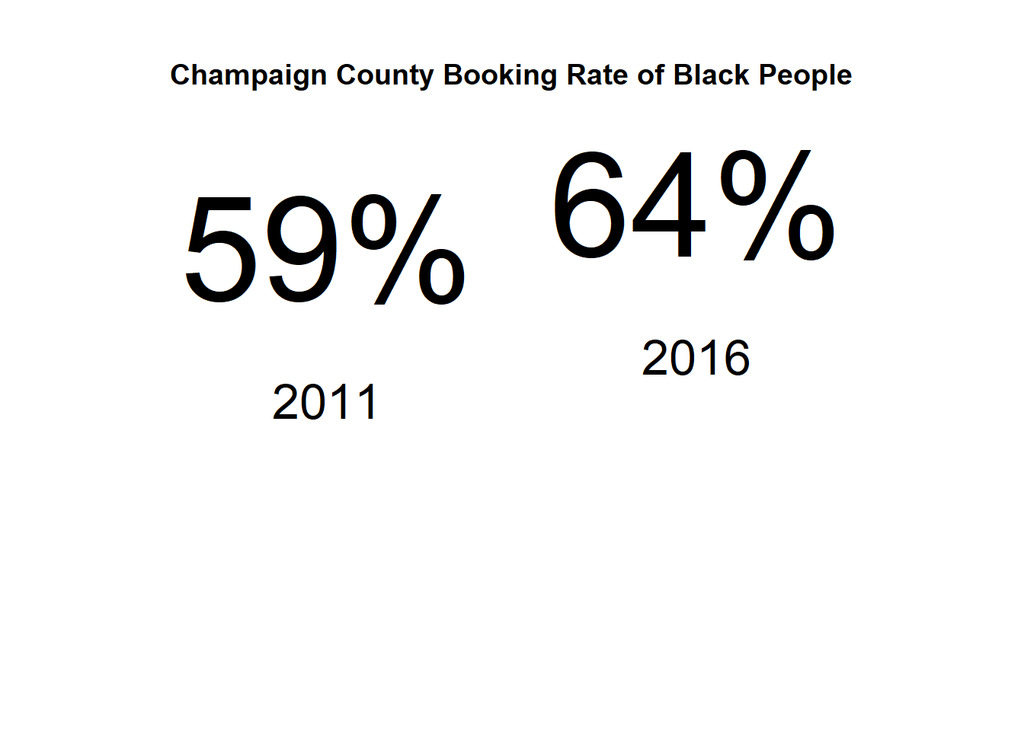

```r
par(mai=c(0,1,1,1))
barplot(rb,col="white", main="Champaign County Booking Rate of Black People",axes = FALSE, border=NA)
text(rbp, rb, label=paste0(round(rb,2)*100,"%",""), pos=1, cex=6)
text(rbp, rb-0.20, label=c("2011","2016"), pos=1, cex=2)
```

```r
par(mar=c(5, 4, 4, 2) + 0.1 )
```

#### Scatter plots

- Scatter plots allow us to display numeric data simultaneously in two dimensions (horizontal and vertical axes)
- Ask yourself whether this plot can be better? The answer is usually yes.

**BAD**

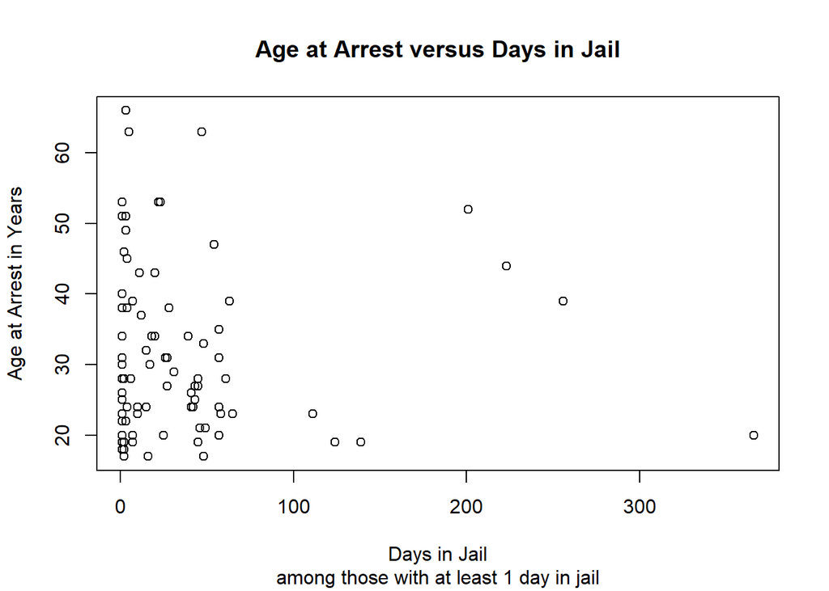

```r
plot(jail$days2[jail$days2>0],jail$`age at arrest`[jail$days2>0],main="Age at Arrest versus Days in Jail", ylab = "Age at Arrest in Years", xlab="Days in Jail", sub="among those with at least 1 day in jail")
```

```r
sa<-summary(jail$`age at arrest`[jail$days2>0])
#table(jail$days[jail$days>0])
```

**GOOD**

```r
length(jail$`crime code`[jail$days2>0 & jail$`age at arrest`<18])
```

```
## [1] 3
```

```r
sort(table(jail$`crime code`[jail$days2>0 & jail$`age at arrest`<18]),decreasing = TRUE)[1:3]
```

```
##
##             MOB ACTION OTHER TRAFFIC OFFENSES    PROBATION VIOLATION
##                      1                      1                      1
```

```r
ycc<-names(sort(table(jail$`crime code`[jail$days2>0 & jail$`age at arrest`<18]),decreasing = TRUE)[1:3])

length(jail$`crime code`[jail$days2>0 & jail$`age at arrest`>=100])
```

```
## [1] 0
```

```r
sort(table(jail$`crime code`[jail$days2>0 & jail$`age at arrest`>=100]),decreasing = TRUE)[1:3]
```

```
## [1] NA NA NA
```

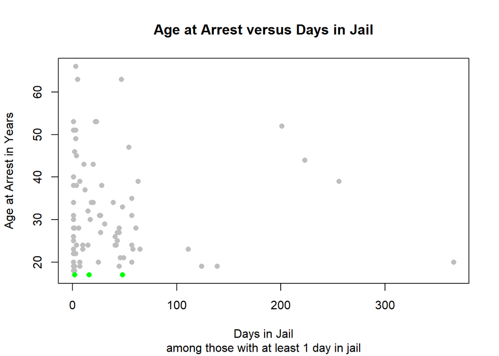

```r
occ<-names(sort(table(jail$`crime code`[jail$days2>0 & jail$`age at arrest`>=100]),decreasing = TRUE)[1:3])

plot(jail$days2[jail$days2>0],jail$`age at arrest`[jail$days2>0],main="Age at Arrest versus Days in Jail", ylab = "Age at Arrest in Years", xlab="Days in Jail", col="gray",sub="among those with at least 1 day in jail",pch=16)
points(jail$days2[jail$days2>0 & jail$`age at arrest`<18],jail$`age at arrest`[jail$days2>0 & jail$`age at arrest`<18] , pch=16, col="green")
points(jail$days2[jail$days2>0 & jail$`age at arrest`>=100],jail$`age at arrest`[jail$days2>0 & jail$`age at arrest`>=100] , pch=16, col="red")
text(x=rep(650,length(ycc)),y=seq(115,100,length.out = 3),label=occ,cex=c(1,0.75,0.5),col="red")
text(x=rep(650,length(ycc)),y=seq(60,45,length.out = 3),label=ycc,cex=c(1,0.75,0.5),col="green")
```

#### Line plots

- Line plots focus the eyes on relative positions in space
- These kinds of plots are good for continuous data (the real line, probabilities, time points)
- Time is best displayed **horizontally and with equidistant tick marks**

**BAD**

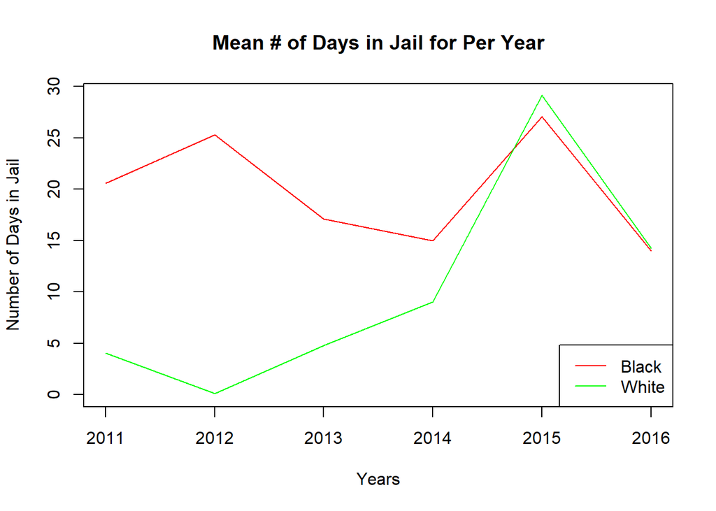

```r
yrs <- split(jail,jail$year2)
daysyrs <- sapply(yrs,function(a){
  mean(a$days2,na.rm =TRUE)
})

daysbla <- sapply(yrs,function(a){
  mean(a$days2[a$race=="Black"],na.rm =TRUE)
})

dayswhi <- sapply(yrs,function(a){
  mean(a$days2[a$race=="White"],na.rm =TRUE)
})

plot(names(daysyrs),daysyrs, type = "n",ylim=c(0,max(daysbla,dayswhi)),xlab="Years",ylab="Number of Days in Jail", main = "Mean # of Days in Jail for Per Year")
lines(names(daysyrs),daysbla, col="red")
lines(names(daysyrs),dayswhi, col="green")
legend("bottomright",c("Black","White"),col = c("red","green"), lty=1)
```

**GOOD**

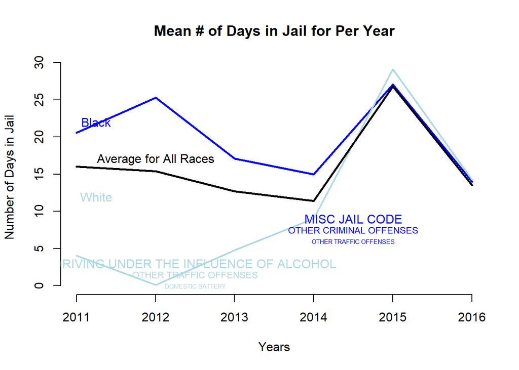

```r
nmb<-names(sort(table(jail$`crime code`[jail$race=="Black"]),decreasing = TRUE)[1:3])
nmw<-names(sort(table(jail$`crime code`[jail$race=="White"]),decreasing = TRUE)[1:3])

plot(names(daysyrs),daysyrs, type = "n",ylim=c(0,max(daysbla,dayswhi)),xlab="Years",ylab="Number of Days in Jail", main = "Mean # of Days in Jail for Per Year",bty="n")
lines(names(daysyrs),daysbla, col="blue",lwd=2.5)
lines(names(daysyrs),dayswhi, col="lightblue", lwd=2)
lines(names(daysyrs),daysyrs, lwd=2.5)
text(2012,17,"Average for All Races")
text(2011.25,22,"Black",col="blue" )
text(2011.25,12,"White",col="lightblue")
text(x=rep(2014.5,length(nmw)),y=seq(9,6,length.out = 3),label=nmb,cex=c(1,0.75,0.5),col="blue")
text(x=rep(2012.5,length(nmb)),y=seq(3,0,length.out = 3),label=nmw,cex=c(1,0.75,0.5),col="lightblue")
```

#### Bar plots

- Bar plots focus the eyes on length from a baseline
- These plots are good for displaying categorical data (categories, groups, levels)
- Carefully consider the ordering of the categories since they are being compared
- Keep in mind: “we” read things from top left to top right, then zigzagging downward in a “z” shape until we end in the bottom right.

**BAD**

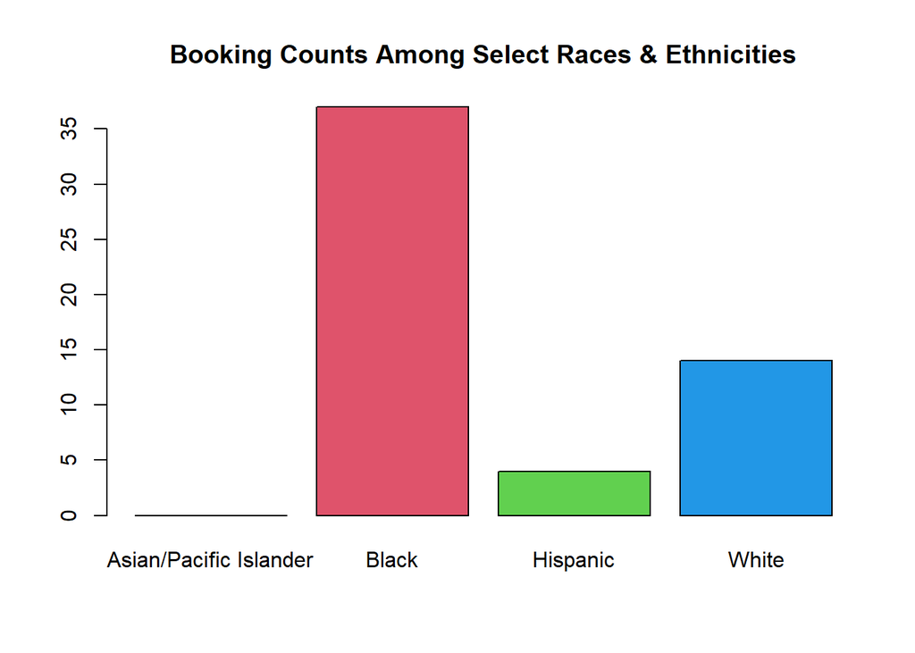

```r
rb0 <- table(jail$race,jail$weeksbin)[,1]
rbp0 <- barplot( rb0,main="Booking Counts Among Select Races & Ethnicities", col=1:length(rb0) , axes=TRUE)
```

```r
rbp0
```

```
##      [,1]
## [1,]  0.7
## [2,]  1.9
## [3,]  3.1
## [4,]  4.3
```

```r
#axis(2, at=seq(2000, 12000, 2000))
```

**GOOD**

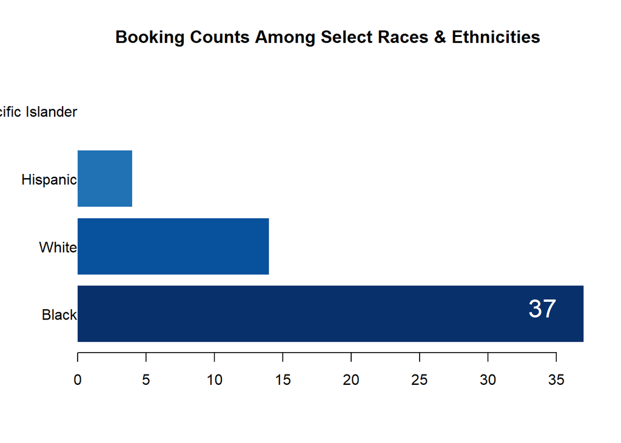

```r
rb0 <- sort(table(jail$race,jail$weeksbin)[,1],decreasing = TRUE)
rbp0 <- barplot( rb0, border=NA ,horiz = TRUE, axes=TRUE,names.arg = "",
                 main="Booking Counts Among Select Races & Ethnicities", col=rev(blues9))
nn <- names(rb0)
axis(2, rbp0, las=1, labels=nn, tick=FALSE,mgp=c(3,-0.25,0))
##axis(1, at=seq(0, 10000, 2000), line=-0.25 )
text(c(34,21,0,0), rbp0+0.4, label=c(rb0[1:2],rep("",length(rb0)-2)), pos=1, cex=1.75, las=1, col="white")
```

#### Plots to be avoided (all from Knaflic’s **Storytelling with Data** book)

- pie charts

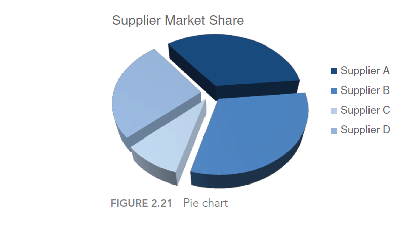

- donut charts

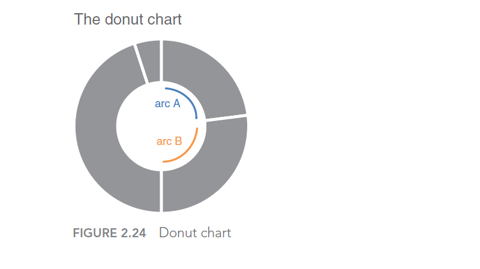

- 3-dimensional (3D) plots

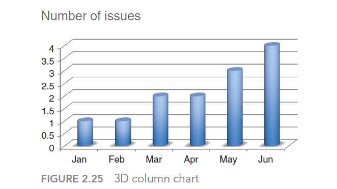

- plots with two or more axes in one dimension

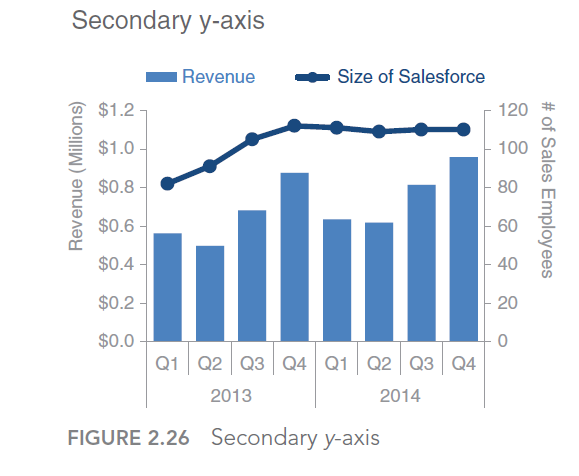

### **Storytelling with Data** *Ch. 3 Clutter Is Your Enemy*

- **Clutter** is any visual thing that does not increase your/our/the audience’s understanding.
- When we take in information that is called **cognitive load**.
- The audience deserves low cognitive load.
- Ideally we want to create data visualizations that are *high signal* (information we want to communicate) and *low noise* (distracting or useless information, i.e. clutter)
- Remove clutter in your plots!

```r
length(jail$`crime code`[jail$days2>0 & jail$`age at arrest`<18])
```

```
## [1] 3
```

```r
ycc<-names(sort(table(jail$`crime code`[jail$days2>0 & jail$`age at arrest`<18]),decreasing = TRUE))
```

**ORIGINAL**

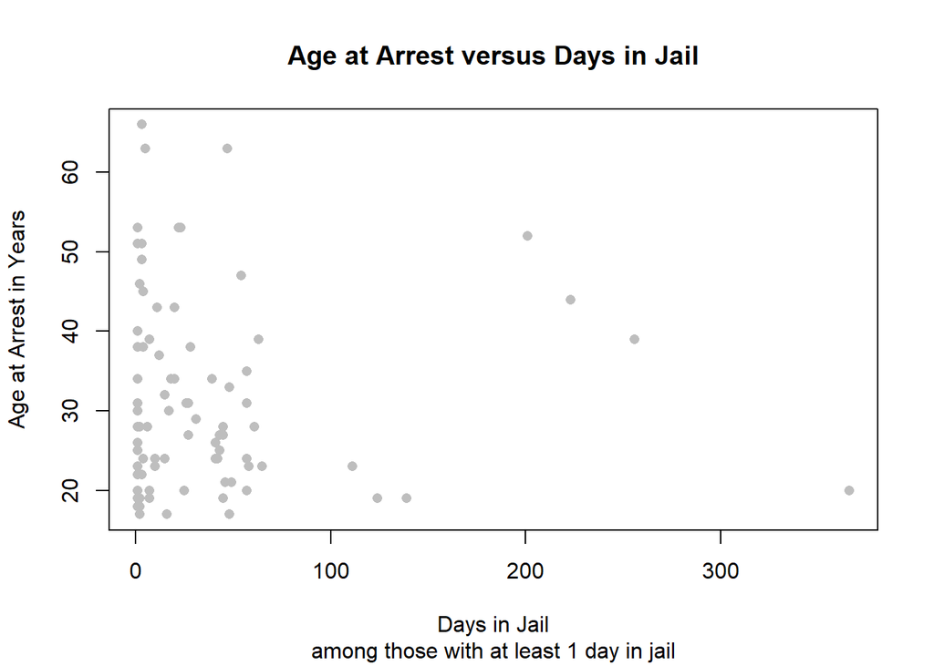

```r
plot(jail$days2[jail$days2>0],jail$`age at arrest`[jail$days2>0],main="Age at Arrest versus Days in Jail", ylab = "Age at Arrest in Years", xlab="Days in Jail", col="gray",sub="among those with at least 1 day in jail",pch=16)
```

#### 6 Gestalt Principles of Visual Perception

1. **proximity**: using space and items to create groups or patterns that guide the eyes

**LESS CLUTTER**

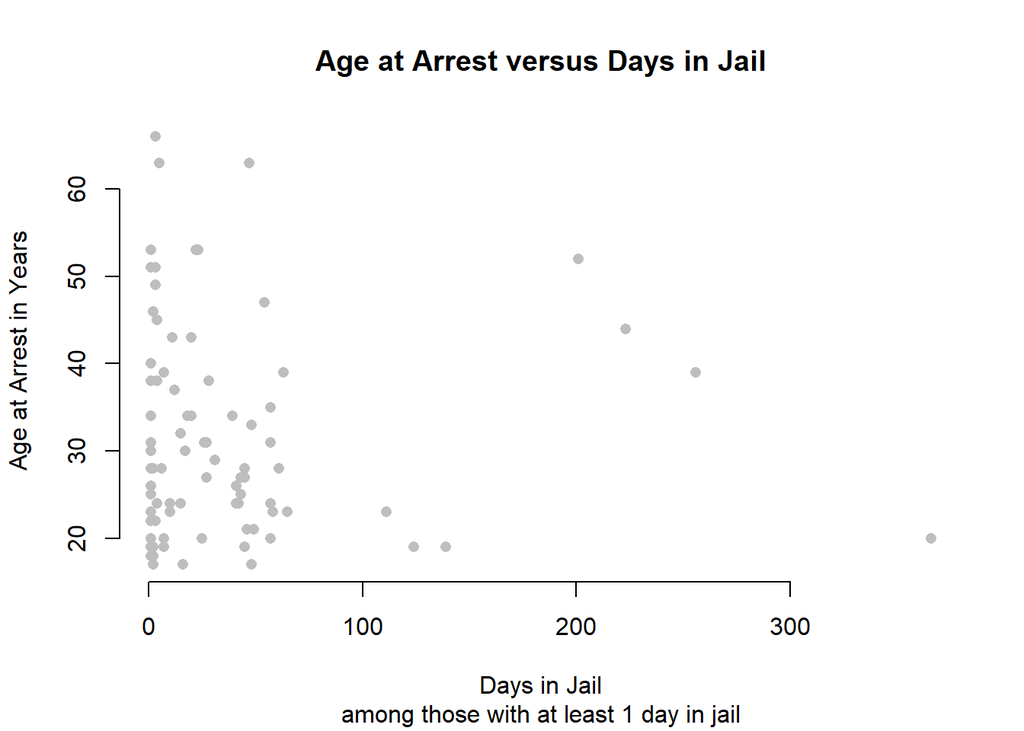

```r
plot(jail$days2[jail$days2>0],jail$`age at arrest`[jail$days2>0],
     main="Age at Arrest versus Days in Jail", ylab = "Age at Arrest in Years", xlab="Days in Jail", col="gray",sub="among those with at least 1 day in jail",
     pch=16, bty="n")
```

2. **similarity**: objects with the same visual cue, such as color, shape, size, or orientation, are in a group

**LESS CLUTTER WITH COLOR**

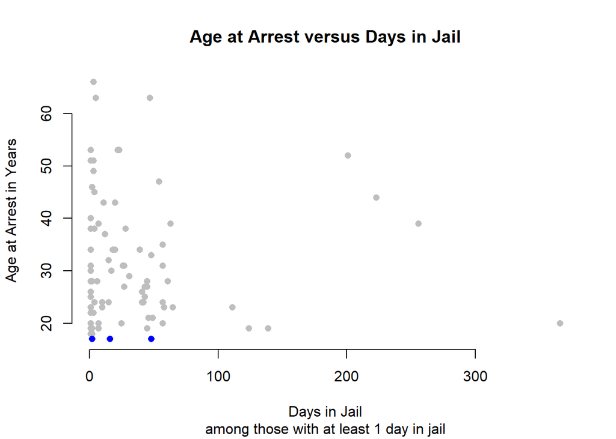

```r
plot(jail$days2[jail$days2>0],jail$`age at arrest`[jail$days2>0],
     main="Age at Arrest versus Days in Jail", ylab = "Age at Arrest in Years",
     xlab="Days in Jail", col="gray",sub="among those with at least 1 day in jail",
     pch=16, bty="n")
points(jail$days2[jail$days2>0 & jail$`age at arrest`<18],
       jail$`age at arrest`[jail$days2>0 & jail$`age at arrest`<18] ,
       pch=16, col="blue")
```

**LESS CLUTTER WITH SHAPE**

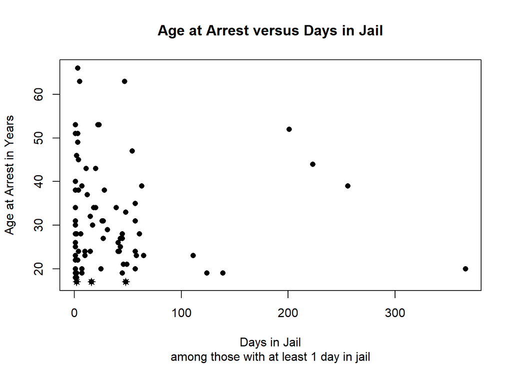

```r
plot(jail$days2[jail$days2>0 & jail$`age at arrest`<100],
     jail$`age at arrest`[jail$days2>0 & jail$`age at arrest`<100],
     ylim=c(min(jail$`age at arrest`[jail$days2>0 & jail$`age at arrest`<100],na.rm=TRUE),max(jail$`age at arrest`[jail$days2>0 & jail$`age at arrest`<100],na.rm=TRUE)),
     main="Age at Arrest versus Days in Jail", ylab = "Age at Arrest in Years",
     xlab="Days in Jail", col=1,sub="among those with at least 1 day in jail",
     pch=16)
points(jail$days2[jail$days2>0 & jail$`age at arrest`<18],
       jail$`age at arrest`[jail$days2>0 & jail$`age at arrest`<18] , pch=8)
```

**LESS CLUTTER WITH SHAPE & COLOR**

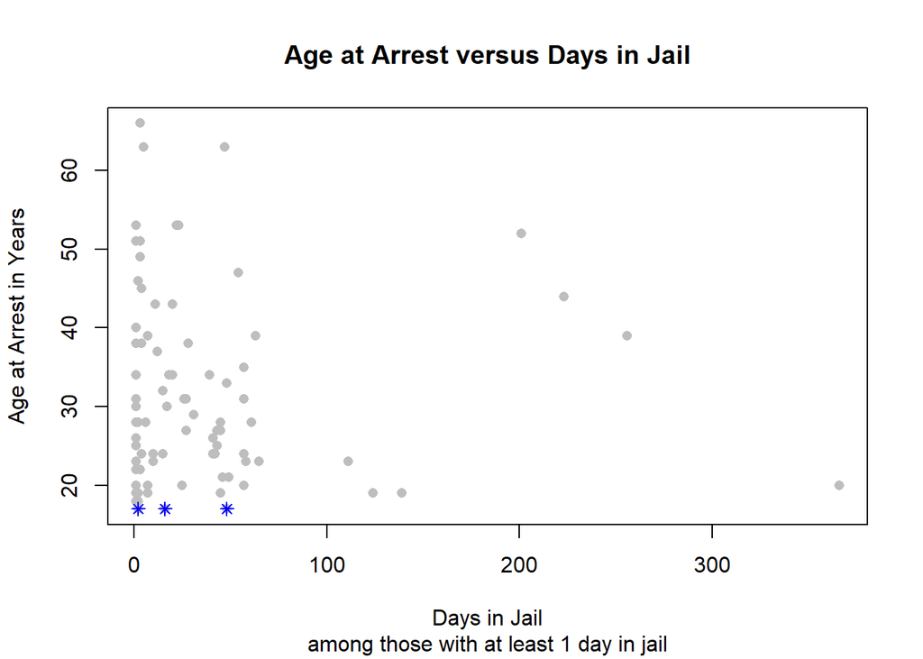

```r
plot(jail$days2[jail$days2>0 & jail$`age at arrest`<100],
     jail$`age at arrest`[jail$days2>0 & jail$`age at arrest`<100],
     ylim=c(min(jail$`age at arrest`[jail$days2>0 & jail$`age at arrest`<100],na.rm=TRUE),max(jail$`age at arrest`[jail$days2>0 & jail$`age at arrest`<100],na.rm=TRUE)),
     main="Age at Arrest versus Days in Jail", ylab = "Age at Arrest in Years",
     xlab="Days in Jail", col="gray",sub="among those with at least 1 day in jail",
     pch=16)
points(jail$days2[jail$days2>0 & jail$`age at arrest`<18],
       jail$`age at arrest`[jail$days2>0 & jail$`age at arrest`<18] ,
       pch=8, col="blue")
```

3. **enclosure**: items that are enclosed or bounded are in a group

**LESS CLUTTER WITH A BOX ENCLOSURE**

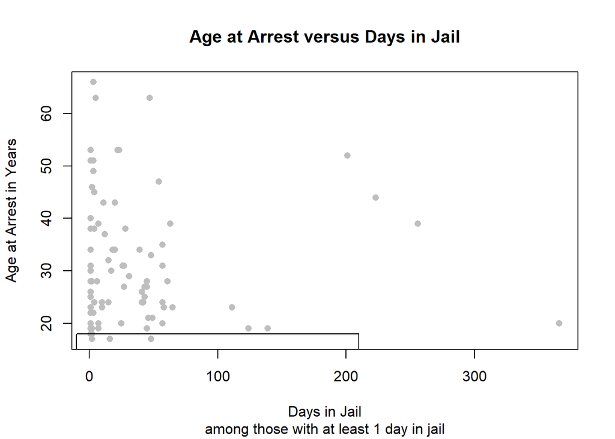

```r
plot(jail$days2[jail$days2>0],jail$`age at arrest`[jail$days2>0],
     main="Age at Arrest versus Days in Jail", ylab = "Age at Arrest in Years",
     xlab="Days in Jail", col="gray",sub="among those with at least 1 day in jail",
     pch=16)
rect(-10,18,210,15)
```

**LESS CLUTTER WITH A BAND**

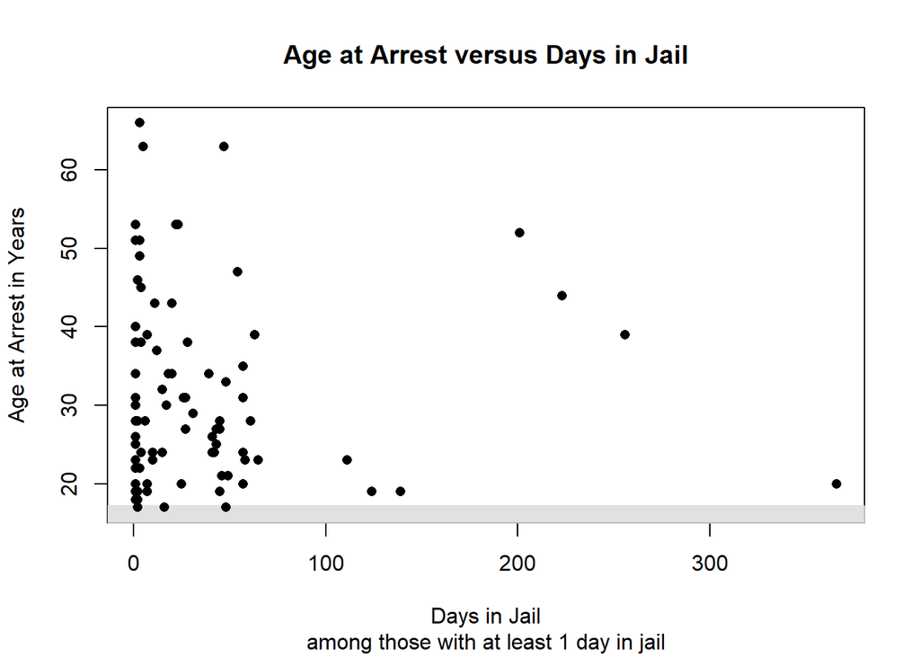

```r
plot(jail$days2[jail$days2>0],jail$`age at arrest`[jail$days2>0],
     main="Age at Arrest versus Days in Jail", ylab = "Age at Arrest in Years",
     xlab="Days in Jail", col=1,sub="among those with at least 1 day in jail",
       type = "n")
abline(h=16,col=rgb(220/255,220/255,220/255,alpha = .85),lwd=15)
points(jail$days2[jail$days2>0],jail$`age at arrest`[jail$days2>0], pch=16)
```

4. **closure**: when we first see items and they appear to be structured or have a certain form

**LESS CLUTTER WITH CLOSURE, ENCLOSURE, & SIMILARITY**

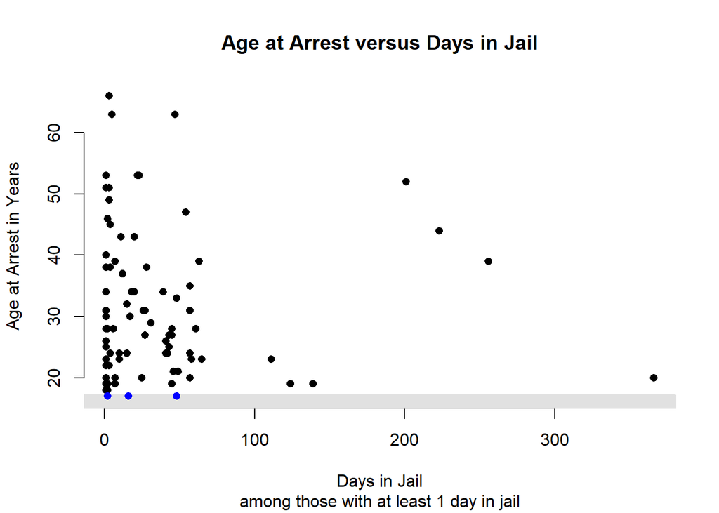

```r
plot(jail$days2[jail$days2>0],jail$`age at arrest`[jail$days2>0],
     main="Age at Arrest versus Days in Jail", ylab = "Age at Arrest in Years",
     xlab="Days in Jail", col=1,sub="among those with at least 1 day in jail",
     pch=16, bty="n")
abline(h=16,col=rgb(220/255,220/255,220/255,alpha = .85),lwd=15)
points(jail$days2[jail$days2>0 & jail$`age at arrest`<18],
       jail$`age at arrest`[jail$days2>0 & jail$`age at arrest`<18] ,
       pch=16, col="blue")
```

5. **continuity**: when we first see objects, we view them along the smoothest paths, which creates continuous flow

**ORIGINAL**

```r
rb0 <- sort(table(jail$race,jail$weeksbin)[,1])
rbp0 <- barplot( rb0, border=NA ,horiz = TRUE, axes=FALSE,names.arg = "",
                 main="Booking Counts Among Select Races & Ethnicities", col="gray")
rb0
```

```
## Asian/Pacific Islander               Hispanic                  White
##                      0                      4                     14
##                  Black
##                     37
```

```r
rbp0
```

```
##      [,1]
## [1,]  0.7
## [2,]  1.9
## [3,]  3.1
## [4,]  4.3
```

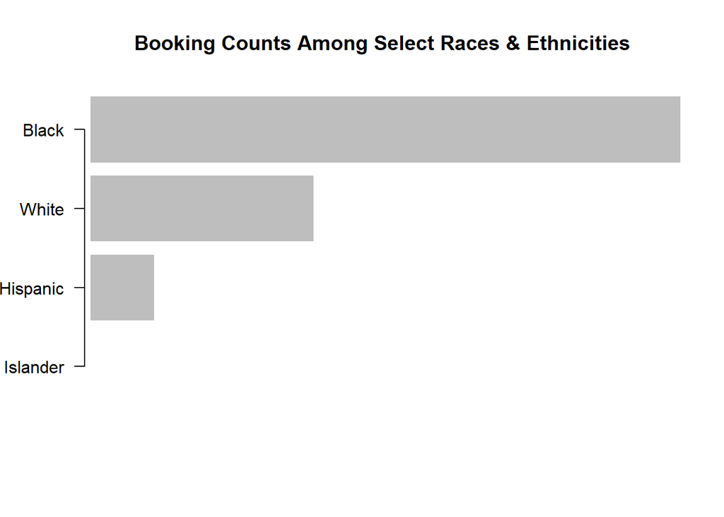

```r
nn <- names(rb0)
nm<-rev(nn)
axis(2, rbp0, las=1, labels=nn, tick=TRUE)
```

```r
#axis(1, at=seq(0, 10000, 2000), line=-0.25 )
#text(rev(c((rb0-1100)[1],4650,500,0,0)), rbp0+0.4, label=c(rb0[1:3],rep("",length(rb0)-3)), pos=1, cex=1.75, las=1, col="white")
```

**LESS CLUTTER WITH CONTINUITY**

```r
rb0 <- sort(table(jail$race,jail$weeksbin)[,1])
rbp0 <- barplot( rb0, border=NA ,horiz = TRUE, axes=FALSE,names.arg = "",
                 main="Booking Counts Among Select Races & Ethnicities", col="gray")
rb0
```

```
## Asian/Pacific Islander               Hispanic                  White
##                      0                      4                     14
##                  Black
##                     37
```

```r
rbp0
```

```
##      [,1]
## [1,]  0.7
## [2,]  1.9
## [3,]  3.1
## [4,]  4.3
```

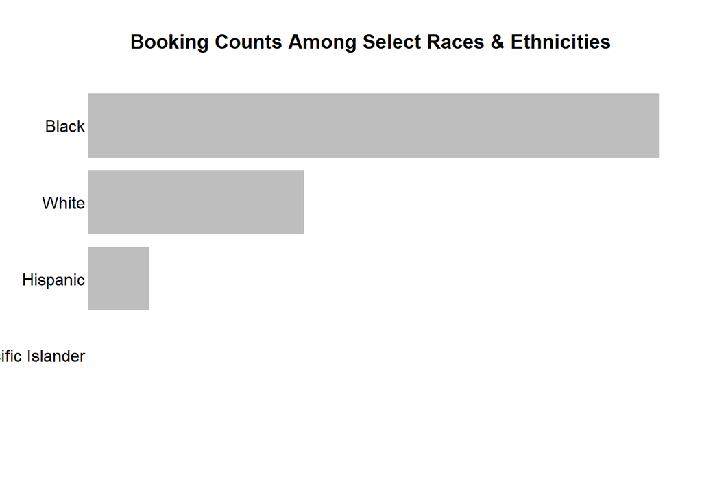

```r
nn <- names(rb0)
nm<-rev(nn)
axis(2, rbp0, las=1, labels=nn, tick=FALSE,mgp=c(3,-0.15,0))
```

```r
#axis(1, at=seq(0, 10000, 2000), line=-0.25 )
#text(rev(c((rb0-1100)[1],4650,500,0,0)), rbp0+0.4, label=c(rb0[1:3],rep("",length(rb0)-3)), pos=1, cex=1.75, las=1, col="white")
```

6. **connection**: when we first see items, we view them as physically connected before we notice other attributes

**ORIGINAL**

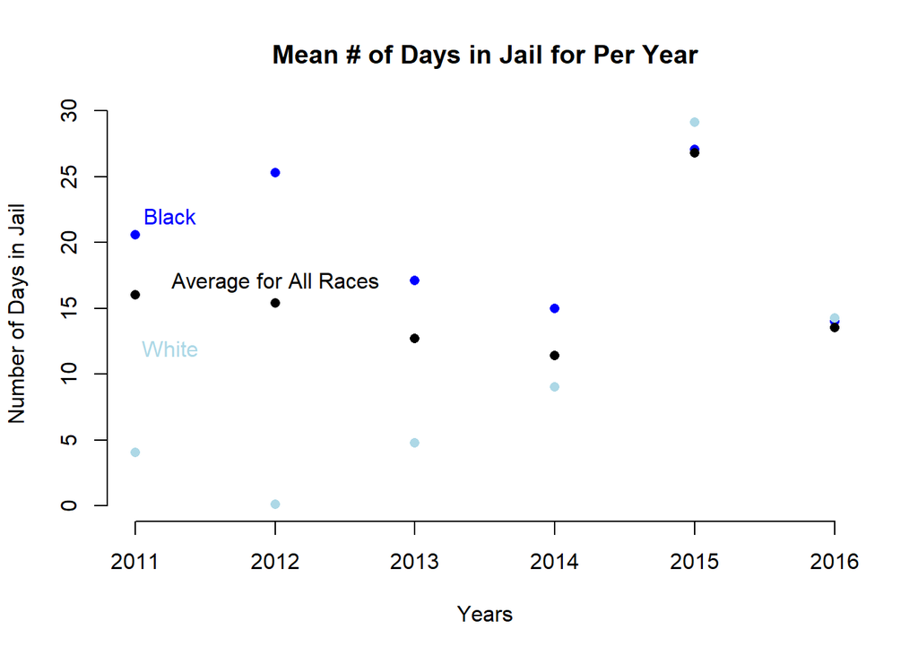

```r
plot(names(daysyrs),daysyrs, type = "n",ylim=c(0,max(daysbla,dayswhi)),xlab="Years",ylab="Number of Days in Jail", main = "Mean # of Days in Jail for Per Year",bty="n")
points(names(daysyrs),daysbla, col="blue", pch=16, lwd=2)
points(names(daysyrs),dayswhi, col="lightblue",pch=16, lwd=2)
points(names(daysyrs),daysyrs, lwd=2,pch=16)
text(2012,17,"Average for All Races")
text(2011.25,22,"Black",col="blue" )
text(2011.25,12,"White",col="lightblue")
```

**LESS CLUTTER WITH CONNECTION**

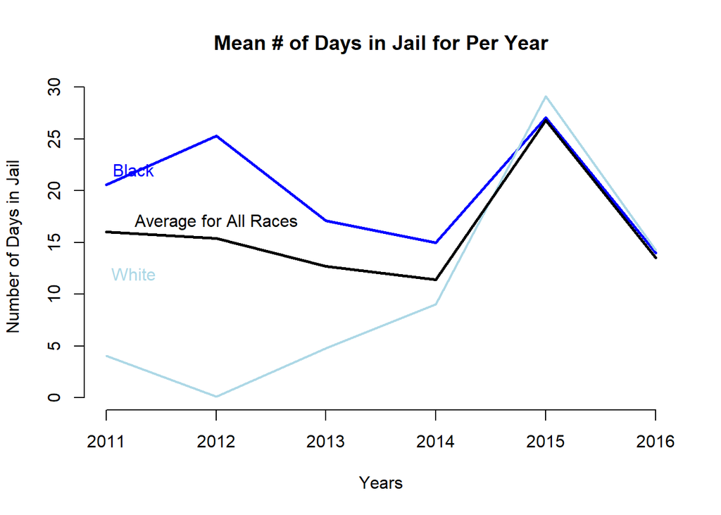

```r
plot(names(daysyrs),daysyrs, type = "n",ylim=c(0,max(daysbla,dayswhi)),xlab="Years",ylab="Number of Days in Jail", main = "Mean # of Days in Jail for Per Year",bty="n")
lines(names(daysyrs),daysbla, col="blue",lwd=2.5)
lines(names(daysyrs),dayswhi, col="lightblue", lwd=2)
lines(names(daysyrs),daysyrs, lwd=2.5)
text(2012,17,"Average for All Races")
text(2011.25,22,"Black",col="blue" )
text(2011.25,12,"White",col="lightblue")
```